# Assignment 3

Assignment 3 i kurset Data Science 2021

Karoline Midtbø

Morten Knutsen

```r
library(readr)
library(tibble)
library(prettydoc)
library(knitr)
library(tidyverse)
library(styler)
library(dplyr)
options(scipen = 999)
```

### Oppgave 1.

Filen ddf_concepts.csv inneholder informasjon om ulike konspeter som skal måles i prosent, men inneholder ingen verdier. De ulike konseptene er for eksempel voksne med hiv, arbeidsledighet, alder på kvinner som gifter seg for første gang, antall nye rapporterte saker og flere andre.

### Oppgave 2.

Filen ddf–entities–geo–country.csv viser til flere ulike land, men innholder ingen verdier her heller. De inkluderte land er Australia, Kongo, Belgia, Østeriket og mange flere. Det er også vist til hvilket kontigent de hører til.

### Oppgave 3.

Filen ddf–entities–geo–un_sdg_region.csv inneholder ulike land og hvilken region de hører til, og blir fremstilt som TRUE eller FALSE.

### Oppgave 4.

Gapminder inneholder variablene:

1. Country: 142
2. Continent: 5 (Africa, Americas, Asia, Europe, Oceania )
3. Year; 1952–2007
4. lifeExp: le at birth in years
5. pop: population
6. gdbPercap: in US $, inflation-adjusted

### Oppgave 5.

```r
g_c <- read_csv("data/ddf--entities--geo--country.csv")
print(g_c)
```

```
## # A tibble: 273 × 22
##    country   g77_and_oecd_countries income_3groups income_groups   `is--country`
##    <chr>     <chr>                  <chr>          <chr>           <lgl>
##  1 abkh      others                 <NA>           <NA>            TRUE
##  2 abw       others                 high_income    high_income     TRUE
##  3 afg       g77                    low_income     low_income      TRUE
##  4 ago       g77                    middle_income  lower_middle_i… TRUE
##  5 aia       others                 <NA>           <NA>            TRUE
##  6 akr_a_dhe others                 <NA>           <NA>            TRUE
##  7 ala       others                 <NA>           <NA>            TRUE
##  8 alb       others                 middle_income  upper_middle_i… TRUE
##  9 and       others                 high_income    high_income     TRUE
## 10 ant       others                 <NA>           <NA>            TRUE
## # … with 263 more rows, and 17 more variables: iso3166_1_alpha2 <chr>,
## #   iso3166_1_alpha3 <chr>, iso3166_1_numeric <dbl>, iso3166_2 <chr>,
## #   landlocked <chr>, latitude <dbl>, longitude <dbl>,
## #   main_religion_2008 <chr>, name <chr>, un_sdg_ldc <chr>,
## #   un_sdg_region <chr>, un_state <lgl>, unhcr_region <chr>,
## #   unicef_region <chr>, unicode_region_subtag <chr>, world_4region <chr>,
## #   world_6region <chr>
```

```r
spec(g_c)
g_c <- g_c %>%
  mutate(continent = case_when(
    world_4region == "asia" & un_sdg_region %in%
      c("un_australia_and_new_zealand", "un_oceania_exc_australia_and_new_zealand") ~ "Oceania",
    world_4region == "asia" & !(un_sdg_region %in%
      c("un_australia_and_new_zealand", "un_oceania_exc_austalia_new_zealand")) ~ "Asia",
    world_4region == "africa" ~ "Africa",
    world_4region == "americas" ~ "Americas",
    world_4region == "europe" ~ "Europe")
  ) %>%
  filter(!is.na(iso3166_1_alpha3))
```

### Oppgave 6a.

```r
length(unique(g_c$country))
```

```
## [1] 247
```

### Oppgave 6b.

```r
g_c %>%
  group_by(continent) %>%
  summarise(countries = length(unique(country)))
```

| continent | countries |
| --- | --- |
| Africa | 59 |
| Americas | 55 |
| Asia | 47 |
| Europe | 58 |
| Oceania | 28 |

### Oppgave 7.

```r
lifeExp <- read_csv("data/countries-etc-datapoints/ddf--datapoints--life_expectancy_years--by--geo--time.csv",
  col_types = cols(time = col_date(format = "%Y")))
lifeExp <- lifeExp %>%
  rename (year = time)
length(unique(lifeExp$geo))
```

```
## [1] 195
```

```r
names(lifeExp)
```

```
## [1] "geo"                   "year"                  "life_expectancy_years"
```

### Oppgave 8.

```r
length(unique(lifeExp$geo))
```

```
## [1] 195
```

Vi finne ut at det er 195 land som sitter med denne informasjonen.

### Oppgave 9.

```r
g_c <- g_c %>%
  select(country, name, iso3166_1_alpha3,un_sdg_region,world_4region,continent,world_6region) %>%
  left_join(lifeExp, by = c("country" = "geo"))
names(g_c)
```

```
## [1] "country"               "name"                  "iso3166_1_alpha3"
## [4] "un_sdg_region"         "world_4region"         "continent"
## [7] "world_6region"         "year"                  "life_expectancy_years"
```

### Oppgave 10.

```r
g_c_min <- g_c %>%
group_by(country) %>%
summarise(min_year = min(year))
table(g_c_min$min_year)
```

```
##
## 1800-01-01 1950-01-01
##        186          9
```

### Oppgave 11.

```r
g_c_min <- g_c_min %>%
  left_join(g_c,
            by = "country") %>%
  filter(min_year == "1950-01-01")
tibble(country = unique(g_c_min$name))
```

| country |
| --- |
| Andorra |
| Dominica |
| St. Kitts and Nevis |
| Monaco |
| Marshall Islands |
| Nauru |
| Palau |
| San Marino |
| Tuvalu |

### Oppgave 12

```r
pop <- read_csv("data/countries-etc-datapoints/ddf--datapoints--population_total--by--geo--time.csv",
  col_types = cols(
  time = col_date(format = "%Y")))
```

```r
g_c <- g_c %>%
  left_join(pop, by = c("country" = "geo", "year" = "time"))
```

### Oppgave 13

```r
gdp_pc <- read_csv("data/countries-etc-datapoints/ddf--datapoints--gdppercapita_us_inflation_adjusted--by--geo--time.csv",
col_types = cols(
  time = col_date(format = "%Y")))
```

```r
g_c <- g_c %>%
  left_join(gdp_pc, by = c("country" = "geo", "year" = "time"))
rm(gdp_pc)
```

```r
g_c = g_c %>%
  rename(lifeExp = life_expectancy_years,
         pop = population_total,
         gdpPercap = gdppercapita_us_inflation_adjusted)
```

### Oppgave 14

```r
t2 <- paste(c(seq(1800,2015, by = 5),2019),"01-01", sep = "-") %>%
  parse_date(format = "%Y-%m-%d")


g_c_5 <- g_c %>%
  filter(year %in% t2) %>%
  select(country, name, continent, year, lifeExp, pop, gdpPercap)

dim(g_c_5)
```

```
## [1] 8505    7
```

```r
g_c_min <- g_c_5 %>%
group_by(gdpPercap) %>%
summarise(year_min = min(year))
```

```r
g_c_min %>%
count(year_min = g_c_min$year_min)
```

| year_min | n |
| --- | --- |
| 1800-01-01 | 1 |
| 1960-01-01 | 86 |
| 1965-01-01 | 93 |
| 1970-01-01 | 108 |
| 1975-01-01 | 112 |
| 1980-01-01 | 133 |
| 1985-01-01 | 142 |
| 1990-01-01 | 161 |
| 1995-01-01 | 178 |
| 2000-01-01 | 186 |

[output cut: 4 more lines]

### Oppgave 15

```r
g_c <- g_c %>%
  filter(!is.na(gdpPercap)) %>%
  group_by(country) %>%
  summarise(nr=n()) %>%
  arrange((country))
```

```r
g_c_60 <- g_c %>%
  filter(nr > 60)
```

Vi får 84 observasjoner som har rappotert GDPperkap i 60 år eller mer.

### Oppgave 16

```r
c_min_y <- g_c_5 %>%
filter(!is.na(gdpPercap)) %>%
group_by(country) %>%
summarise(min_year = min(year))
```

```r
dim(c_min_y)
```

```
## [1] 191   2
```

```r
c_min_y_60 <- c_min_y$country[c_min_y$min_year == "1960-01-01"]
my_gapminder_1960 <- g_c_5 %>%
filter(country %in% c_min_y_60)
```

```r
# vi sjekker hvor mange observasjoner og variabler det er.
dim(my_gapminder_1960)
```

```
## [1] 3870    7
```

```r
# her ser vi antall land som har refistrert data mellom 1960 og 2019
length(unique(my_gapminder_1960$country))
```

```
## [1] 86
```

Her ser vi hvor mange NA observasjoner det er. 2754.

```r
(num_NA <- my_gapminder_1960[is.na(my_gapminder_1960$gdpPercap) == TRUE, ])
```

| country | name | continent | year | lifeExp | pop | gdpPercap |
| --- | --- | --- | --- | --- | --- | --- |
| arg | Argentina | Americas | 1800-01-01 | 33.20 | 534000 | NA |
| arg | Argentina | Americas | 1805-01-01 | 33.20 | 465622 | NA |
| arg | Argentina | Americas | 1810-01-01 | 33.20 | 419661 | NA |
| arg | Argentina | Americas | 1815-01-01 | 33.20 | 465972 | NA |
| arg | Argentina | Americas | 1820-01-01 | 33.20 | 530996 | NA |
| arg | Argentina | Americas | 1825-01-01 | 33.20 | 582027 | NA |
| arg | Argentina | Americas | 1830-01-01 | 33.20 | 634974 | NA |
| arg | Argentina | Americas | 1835-01-01 | 33.20 | 698047 | NA |
| arg | Argentina | Americas | 1840-01-01 | 33.20 | 776366 | NA |
| arg | Argentina | Americas | 1845-01-01 | 33.20 | 920317 | NA |

[output cut: 2744 more lines]

Denne modellen er ikke så oversiktilig, så vi kan velge og ta i bruk paste() funksjonen for å få frem svaret.

```r
paste("Number of NAs in my_gapminder_1960 is", dim(num_NA)[1], sep = " ")
```

```
## [1] "Number of NAs in my_gapminder_1960 is 2754"
```

```r
my_gapminder_1960 %>%
distinct(country, continent) %>%
group_by(continent) %>%
count() %>%
kable()
```

| continent | n |
| --- | --- |
| Africa | 29 |
| Americas | 25 |
| Asia | 14 |
| Europe | 15 |
| Oceania | 3 |

### Oppgave 17

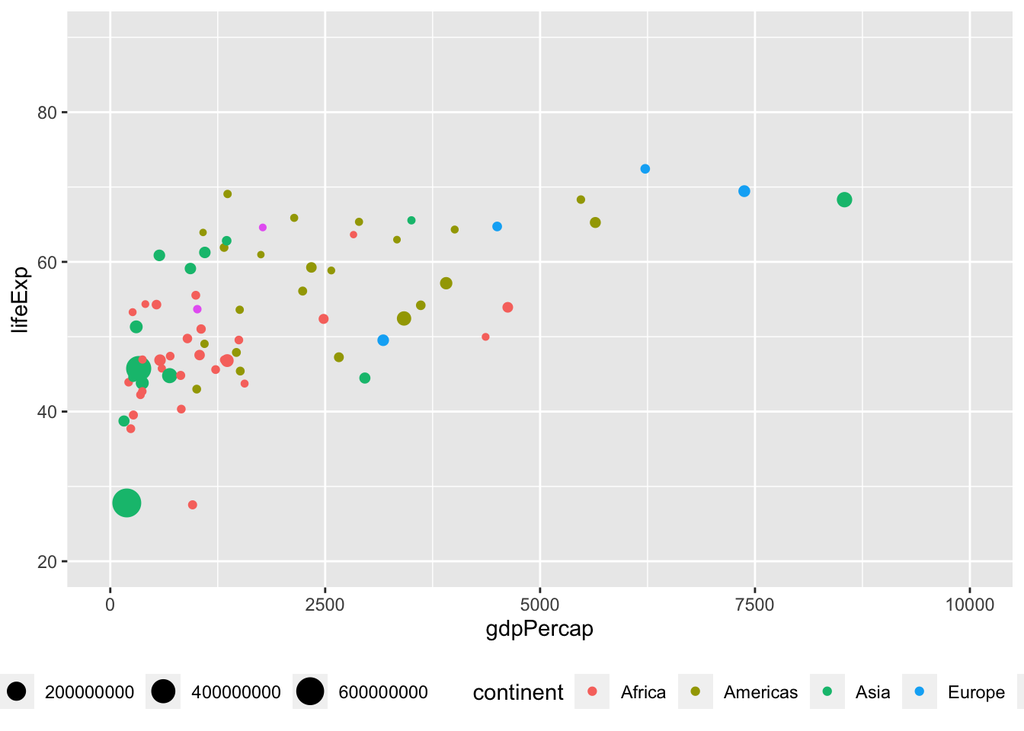

```r
my_gapminder_1960 %>%
filter(year <= "1960-01-01") %>%
ggplot(mapping = aes(x = gdpPercap, y = lifeExp, size = pop, colour = continent)) +
geom_point() +
coord_cartesian(ylim = c(20, 90), xlim = c(0,10000)) +
theme(legend.position = "bottom")
```

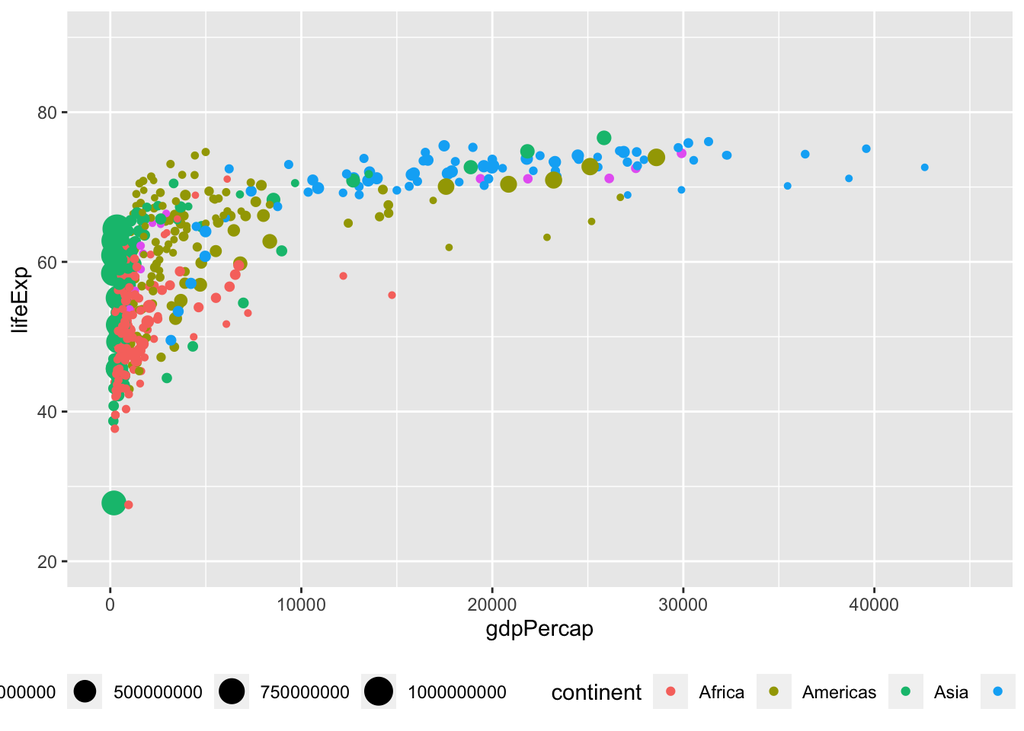

```r
my_gapminder_1960 %>%
filter(year <= "1980-01-01") %>%
ggplot(mapping = aes(x = gdpPercap, y = lifeExp, size = pop, colour = continent)) +
geom_point() +
coord_cartesian(ylim = c(20, 90), xlim = c(0,45000)) +
theme(legend.position = "bottom")
```

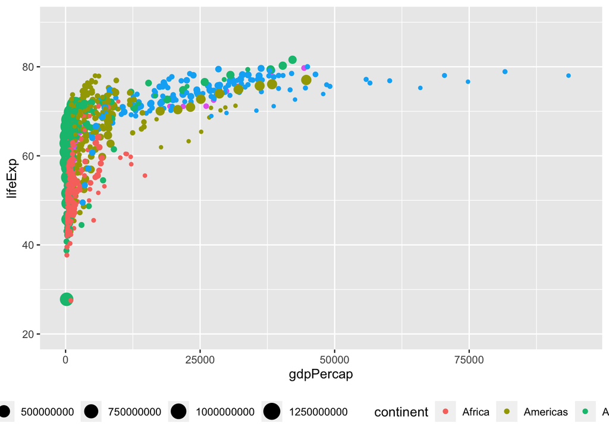

```r
my_gapminder_1960 %>%
filter(year <= "2000-01-01") %>%
ggplot(mapping = aes(x = gdpPercap, y = lifeExp, size = pop, colour = continent)) +
geom_point() +
coord_cartesian(ylim = c(20, 90), xlim = c(0,95000)) +
theme(legend.position = "bottom")
```

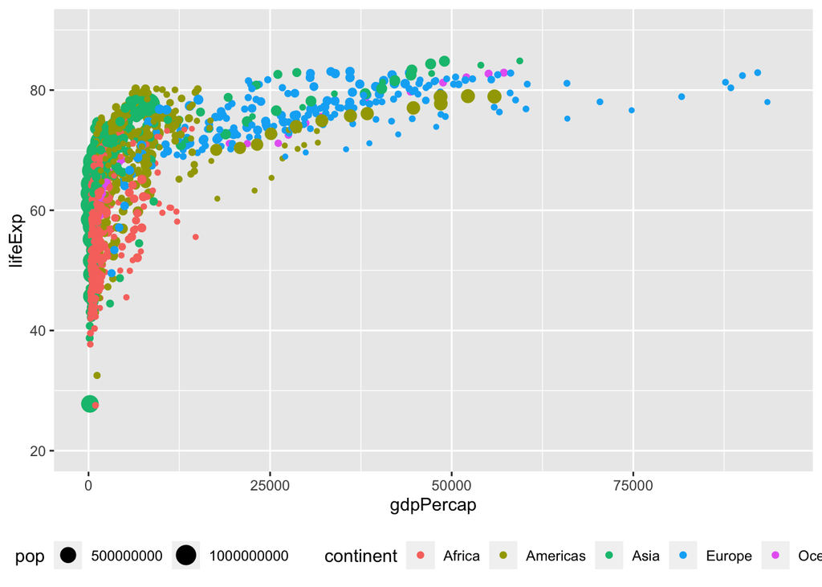

```r
my_gapminder_1960 %>%
filter(year <= "2019-01-01") %>%
ggplot(mapping = aes(x = gdpPercap, y = lifeExp, size = pop, colour = continent)) +
geom_point() +
coord_cartesian(ylim = c(20, 90), xlim = c(0,95000)) +
theme(legend.position = "bottom")
```

### Oppgave 18

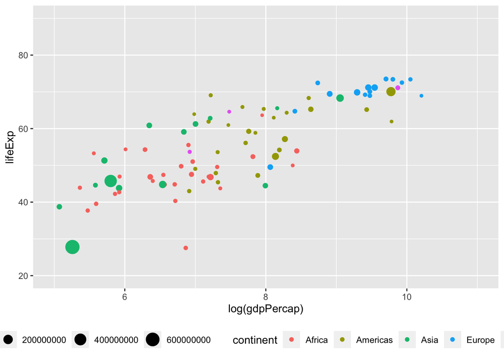

```r
my_gapminder_1960 %>%
filter(year <= "1960-01-01") %>%
ggplot(mapping = aes(x = log(gdpPercap), y = lifeExp, size = pop, colour = continent)) +
geom_point() +
coord_cartesian(ylim = c(20, 90), xlim = c(5,11)) +
theme(legend.position = "bottom")
```

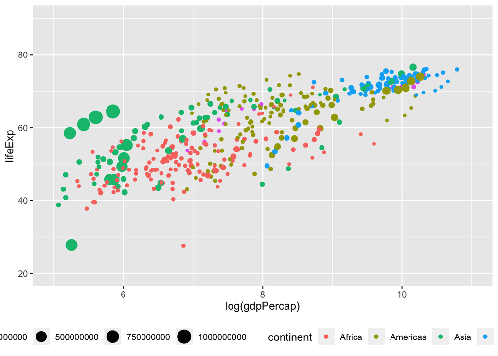

```r
my_gapminder_1960 %>%
filter(year <= "1980-01-01") %>%
ggplot(mapping = aes(x = log(gdpPercap), y = lifeExp, size = pop, colour = continent)) +
geom_point() +
coord_cartesian(ylim = c(20, 90), xlim = c(5,11)) +
theme(legend.position = "bottom")
```

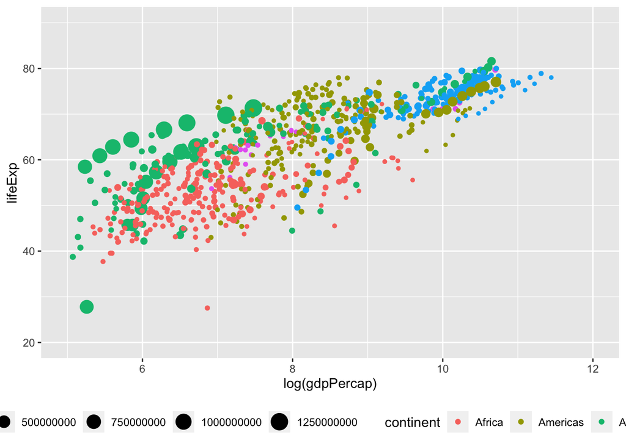

```r
my_gapminder_1960 %>%
filter(year <= "2000-01-01") %>%
ggplot(mapping = aes(x = log(gdpPercap), y = lifeExp, size = pop, colour = continent)) +
geom_point() +
coord_cartesian(ylim = c(20, 90), xlim = c(5,12)) +
theme(legend.position = "bottom")
```

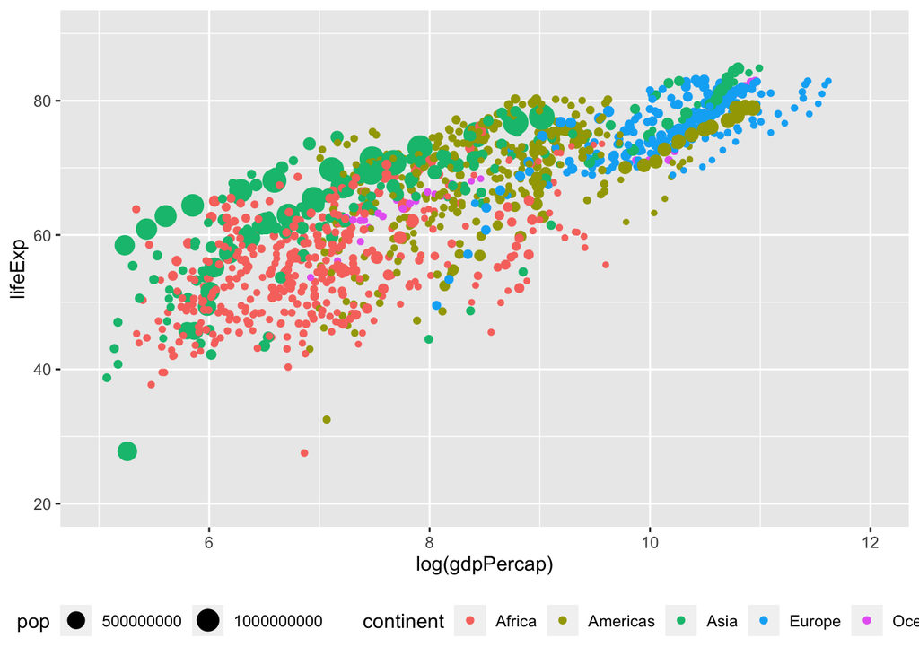

```r
my_gapminder_1960 %>%
filter(year <= "2019-01-01") %>%
ggplot(mapping = aes(x = log(gdpPercap), y = lifeExp, size = pop, colour = continent)) +
geom_point() +
coord_cartesian(ylim = c(20, 90), xlim = c(5,12)) +
theme(legend.position = "bottom")
```

### Oppgave 19

Videre kan vi se at det er en positiv sammenheng mellom BNP og levealder. Noe som gir mening, da økt levestandard vil gi en økt levealder. Vi ser spesielt i Asia at det er land som har fått en økt levealder og BNP. Vi ser også at det er en utvikling i Afrika, men ikke like sterk som Asia.

### Oppgave 20

```r
write.table(g_c, file="my_gapminder.csv", sep = ",")

write.table(g_c_60, file="my_gapminder_red.csv", sep = ",")
```